# Age and Educational Attainment of Women in Kenya: Trends and Gaps

Herbert Allan Maloba

2025-07-04

# Data Overview

This analysis leverages individual-level data for women in Kenya from the DHS. The primary variables include `V013` (Age in 5-year groups) and `V149` (Educational attainment), which capture generational educational progress. To this, we add `V025` (Type of place of residence) to understand urban-rural dynamics, `V024` (Region) for geographical disparities, and `V501` (Current marital status) and `V512` (Age at first marriage) to explore the link with marital status. Missing or ‘not applicable’ values will be carefully managed.

## Introduction

Education is a transformative force, influencing not only individual capabilities but also life choices, including marriage and residential patterns. In Kenya, a country undergoing significant demographic and social change, understanding the complex interplay between age, educational attainment, marital status, and urban-rural residence is paramount. This analysis seeks to explore how these fundamental demographic characteristics shape the lives of Kenyan women, revealing trends and persistent inequalities.

By examining the highest educational attainment among women aged 15-49 across different age cohorts, alongside their marital status and type of residence (urban or rural), we can uncover critical insights. For instance, Are women in urban areas more likely to pursue education for longer and marry later than their rural counterparts? How do these patterns vary across generations, reflecting evolving societal norms and opportunities? Answering these questions is essential for developing comprehensive policies that support women’s empowerment and promote equitable development across all segments of Kenyan society.

**Findings and Analysis**

**Educational Attainment Trends by Age Group**

This section explores how educational attainment varies across different age cohorts of women, highlighting intergenerational trends.

## Chart 1: Overall Educational Attainment

This bar chart illustrates the overall percentage distribution of the highest educational attainment levels among women in the `herbert_decoded` dataset.

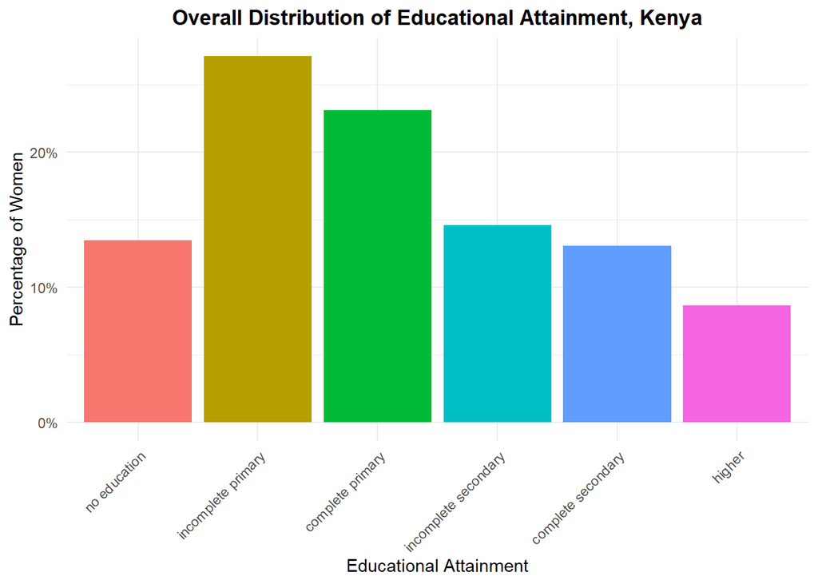

*Interpretation*: This bar chart provides a foundational understanding of the educational landscape among women in Kenya. It reveals the proportion of women at each level of educational attainment, from “no education” to “higher.” Observing the heights of the bars will quickly indicate which educational levels are most prevalent and which are less common, offering insights into the general educational profile of the surveyed population. For instance, a larger bar for “complete primary” or “incomplete secondary” might suggest that a significant portion of women complete basic education but face barriers to advancing further.

### Chart 2: Overall Educational Attainment by Age Group

This bar chart illustrates the percentage distribution of educational attainment across different age groups. It provides insights into how educational levels evolve through different generations of women in Kenya.

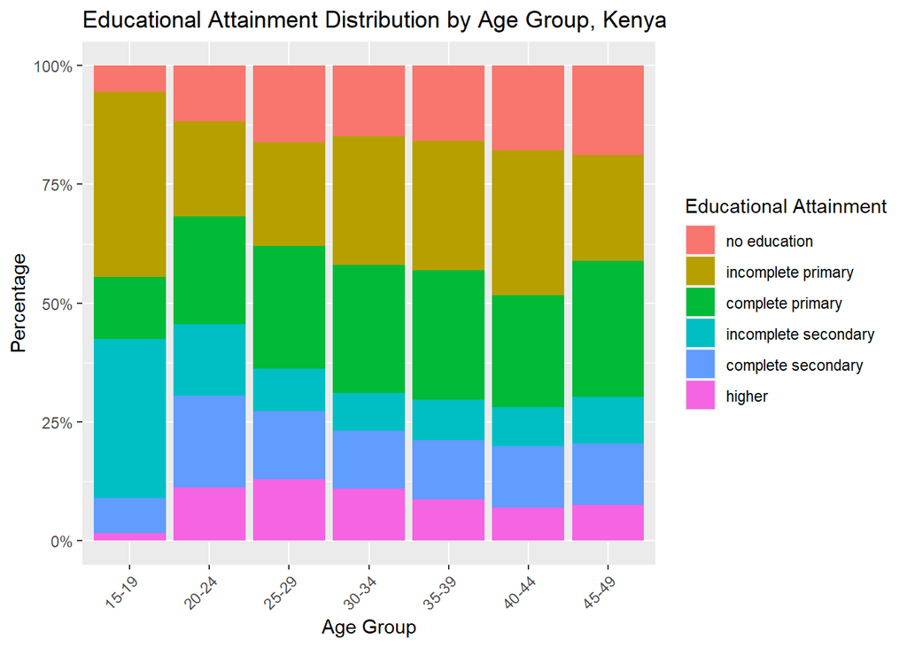

## Gaps in Educational Attainment

This section delves into the disparities in educational attainment based on key socio-demographic factors like residence type and region.

### Chart 3: Educational Attainment Distribution by Region

This stacked column chart illustrates the percentage distribution of educational attainment levels within each region. This provides a clear visualization of regional **gaps** in education.

[figure not shown]